# Preliminary_results: ARDS on young population in FRBDX

Bertrand Moal

**SUMMARY**

**1-Details : for each site**

**2-Flow chart**

**3-Quality control: the objective is to ensure that the data between the center are comparable**

**4-Risk factor analysis: Comparison between ARDS 18-49 versus No ARDS 18-49**

Are there risk factors for ARDS in the population younger than 50 ?

**5-Treatment and outcomes : Comparison ARDS 18-49 versus ARDS >50**

For ARDS patients, could we identify difference between young and old patients in term of

- complication
- treatment ( procedure and medication )
- lab trajectory

**6 - General Descriptive analysis**

# 1 Details

**SITE:** FRBDX

**ARDS detection:** Only ICD-10 J80 or ICD-9 518.82

# 2 Flow chart

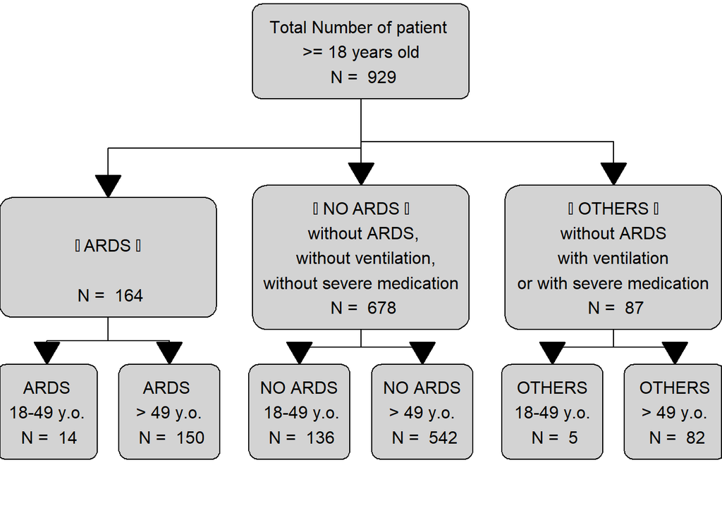

# 3 Quality control

## 3.1 General

**Number of patient in hospital**

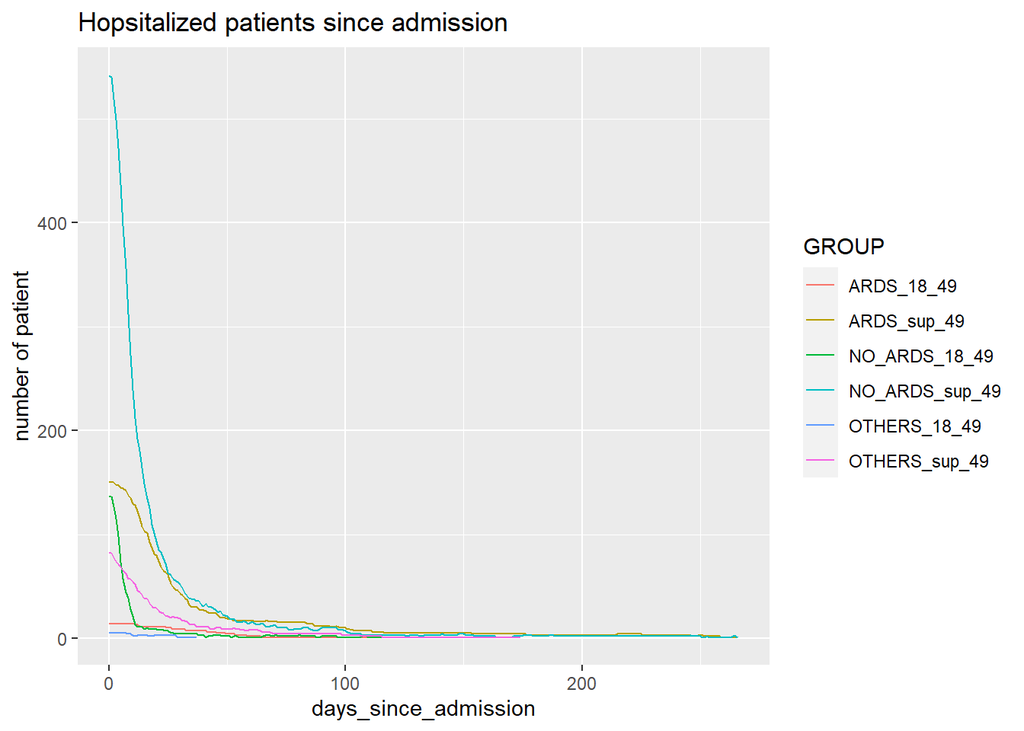

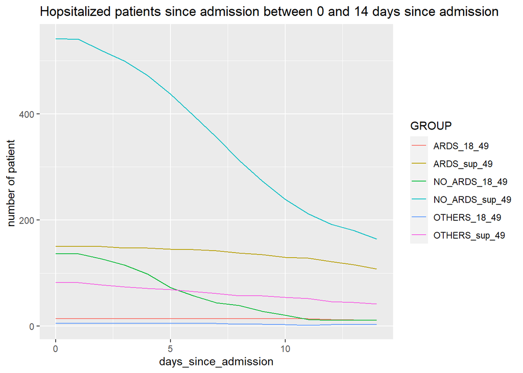

**Distribution of number of associated ICD10 code/Procedure/Medication/Labs per patient**

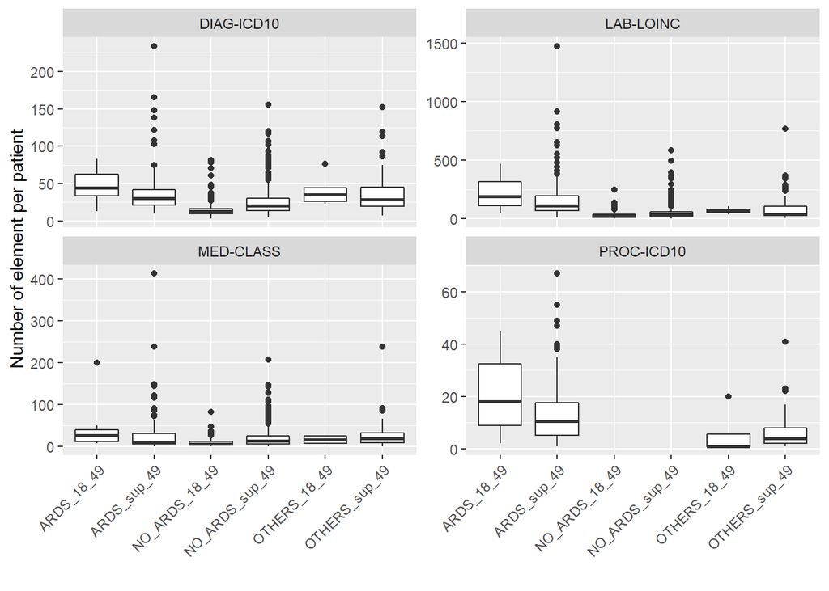

**Number of associated ICD10 code/Procedure/Medication/Labs per patient per day**

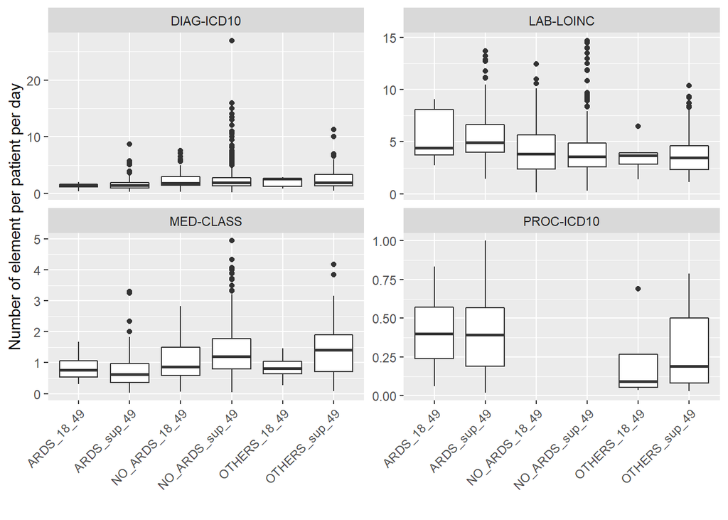

**Lenght of stay per patient**

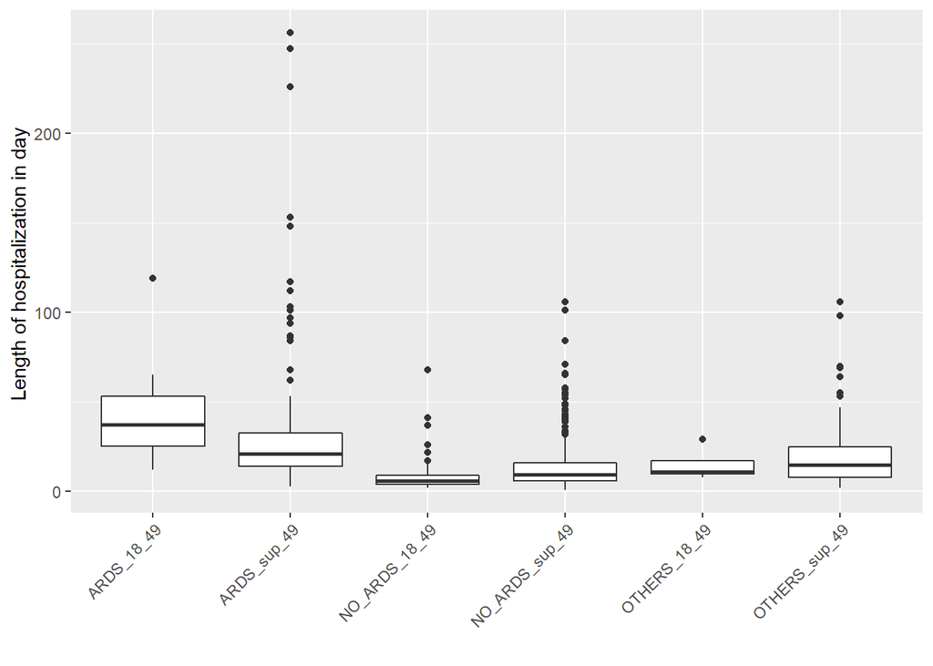

## 3.2 Severity

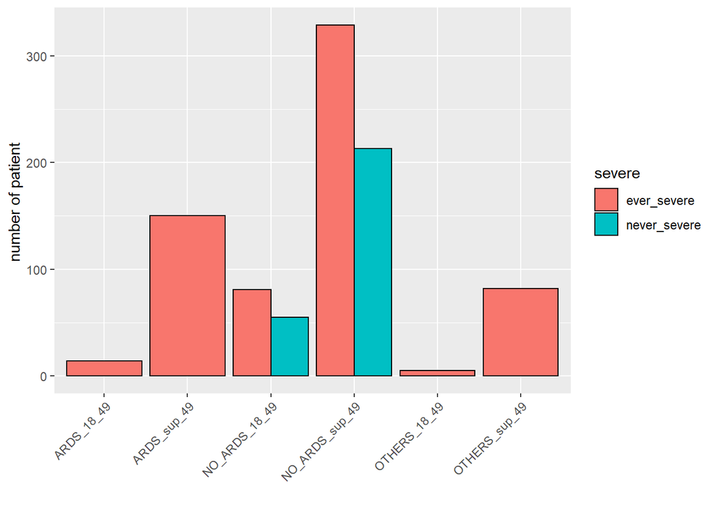

## 3.3 Procedure:Average number of procedure per day

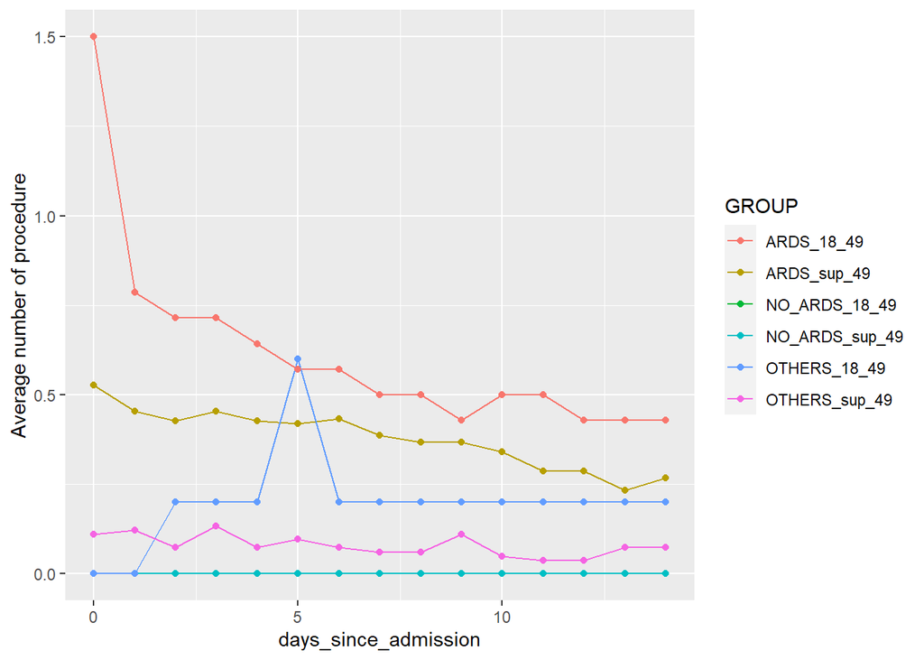

## 3.4 Laboratory :Average number of laboratory per day

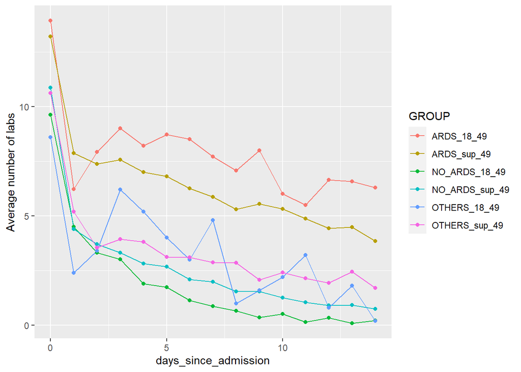

## 3.5 Medication :Average number of medication per day

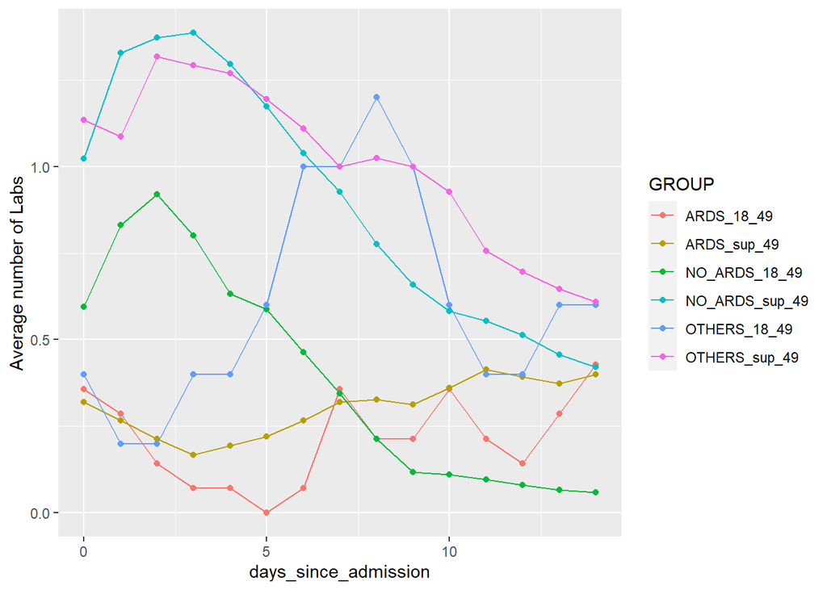

## 3.6 PaO2

**Distribution of number of Pa02 samples per groups**

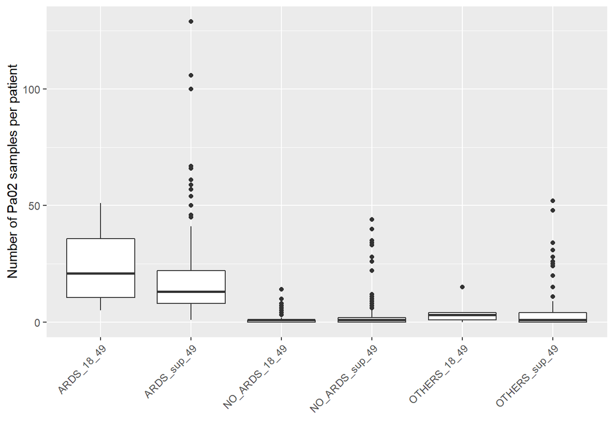

**Average number of PaO2 per patient**

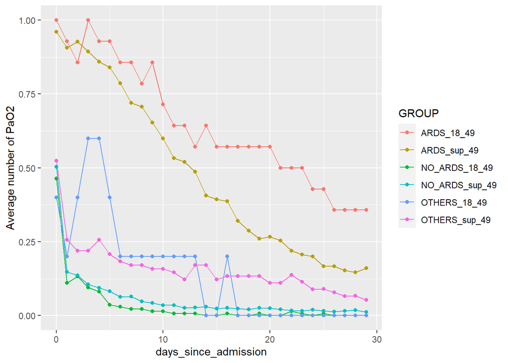

**Distribution of number of Pa02 samples per patient between 5 and 20 day of hospitalization**

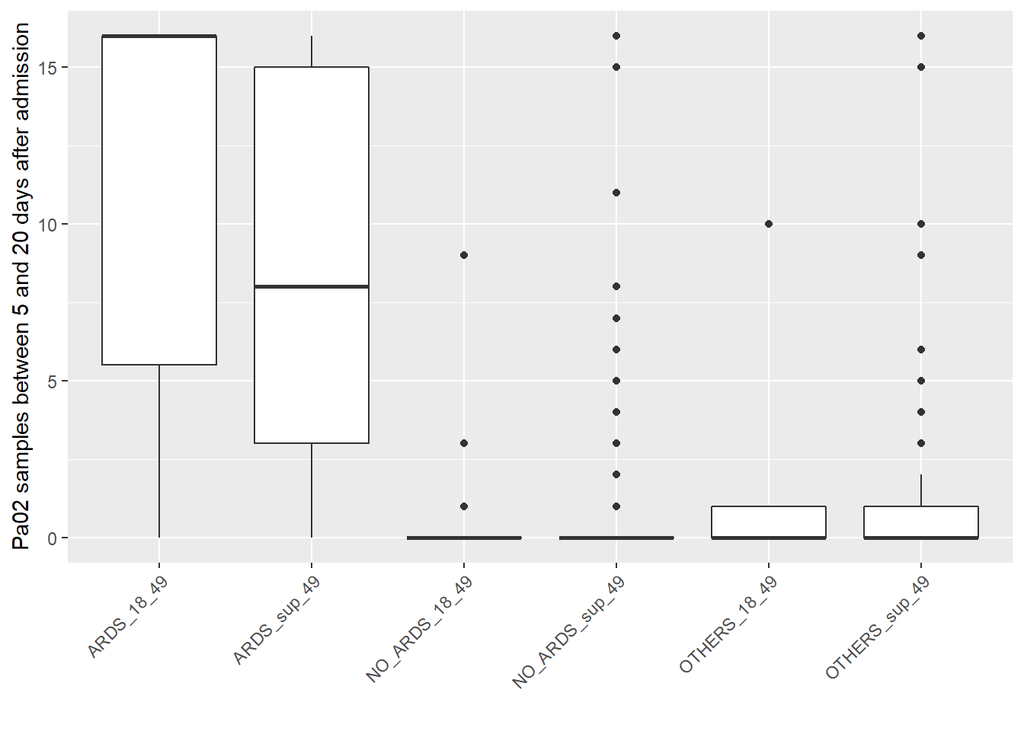

**Distribution of Minimal Pa02 value per group**

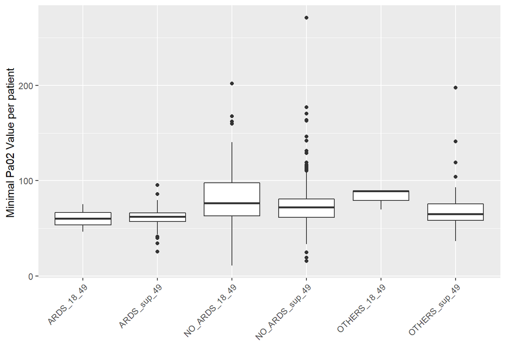

## 3.7 ARDS (ICD-10) versus More than 1 Pa02 between 5 and 20 days after the admission

### 3.7.1 For the entire population

|  | NO ARDS | ARDS |
| --- | --- | --- |
| No Pa02 sample between 5-20 days | 418 | 38 |
| At least one Pa02 sample between 5-20 days | 51 | 125 |

**SENSIBILITY** : 0.77

**PPV** : 0.71

**NPV** : 0.92

**SPECIFITY** : 0.89

### 3.7.2 For the population less than 49 year old

|  | NO ARDS | ARDS |
| --- | --- | --- |
| No Pa02 sample between 5-20 days | 79 | 2 |
| At least one Pa02 sample between 5-20 days | 4 | 12 |

**SENSIBILITY** : 0.86

**PPV** : 0.75

**NPV** : 0.98

**SPECIFITY** : 0.95

# 4 Risk factor analysis: Comparison ARDS 18-49 versus No ARDS 18-49

## 4.1 Demographics

**Age group**

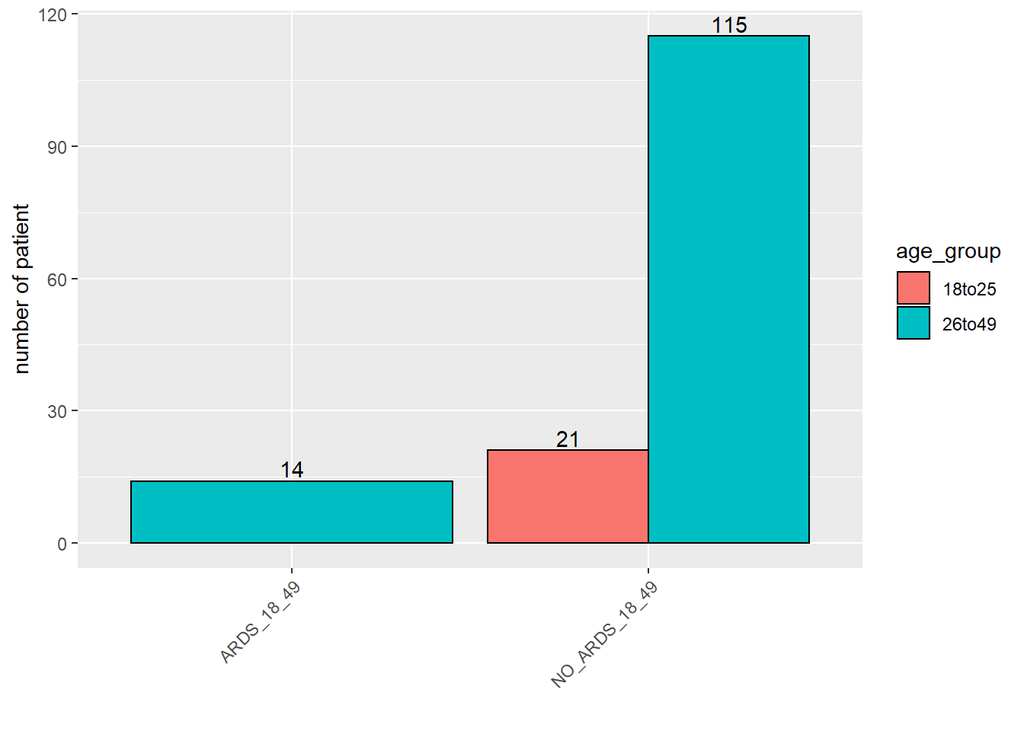

**Sex group**

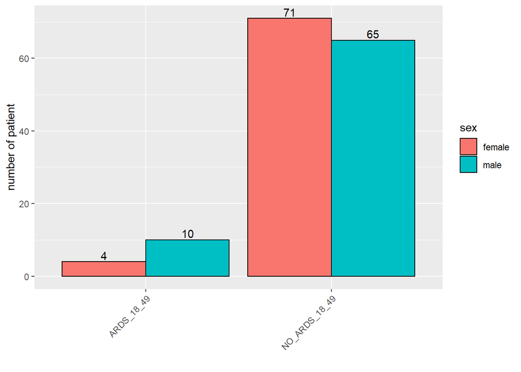

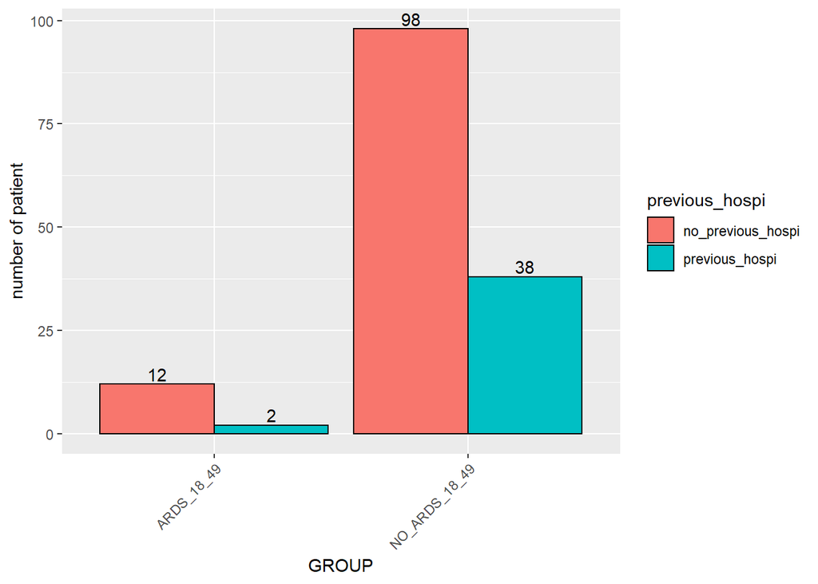

## 4.2 ICD10/9

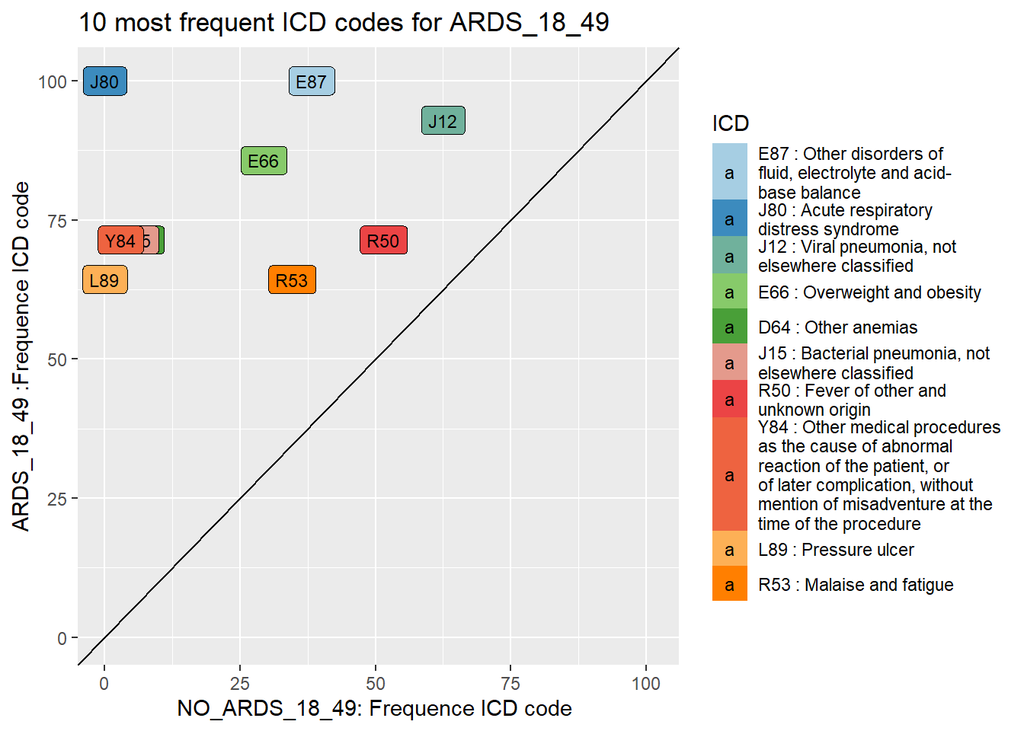

For the 10 most frequent ICD-10/9 codes for the group ARDS 18-49, in x coordinate the frequency(%) of those code for the group No ARDS 18-49 and in y coordinate the frequency(%) of those code for the group ARDS 18-49

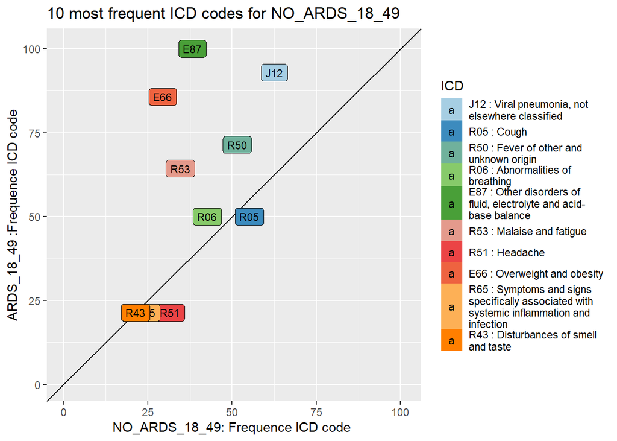

For the 10 most frequent ICD-10/9 codes for the group NO ARDS 18-49, in x coordinate the frequency(%) of those code for the group No ARDS 18-49 and in y coordinate the frequency(%) of those code for the group ARDS 18-49

**Before hospitalization due to covid - Percentage of patients with ICD10/9 code**

| ICD | ICD_title | ARDS_18_49 | NO_ARDS_18_49 |
| --- | --- | --- | --- |
| A09 | Infectious gastroenteritis and colitis, unspecified |  | 2.2 |
| A40 | Streptococcal sepsis |  | 1.5 |
| A41 | Other sepsis |  | 1.5 |
| A46 | Erysipelas |  | 1.5 |
| A53 | Other and unspecified syphilis |  | 0.7 |
| B18 | Chronic viral hepatitis |  | 2.2 |
| B34 | Viral infection of unspecified site |  | 0.7 |
| B37 | Candidiasis |  | 0.7 |
| B50 | Plasmodium falciparum malaria |  | 0.7 |
| B94 | Sequelae of other and unspecified infectious and parasitic diseases |  | 0.7 |

[output cut: 276 more lines]

**After hospitalization due to covid: Percentage of patients with ICD10/9**

| ICD | ICD_title | ARDS_18_49 | NO_ARDS_18_49 |
| --- | --- | --- | --- |
| A02 | Other salmonella infections |  | 0.7 |
| A09 | Infectious gastroenteritis and colitis, unspecified | 35.7 | 8.8 |
| A41 | Other sepsis | 21.4 | 0.7 |
| A46 | Erysipelas |  | 0.7 |
| A55 | Chlamydial lymphogranuloma (venereum) |  | 0.7 |
| A56 | Other sexually transmitted chlamydial diseases |  | 0.7 |
| A87 | Viral meningitis |  | 0.7 |
| B00 | Herpesviral [herpes simplex] infections | 7.1 |  |
| B02 | Zoster [herpes zoster] | 7.1 |  |
| B16 | Acute hepatitis B |  | 0.7 |

[output cut: 381 more lines]

## 4.3 LAB - Comparison between ARDS_18_49 and NO_ARDS_18_49 for the first week

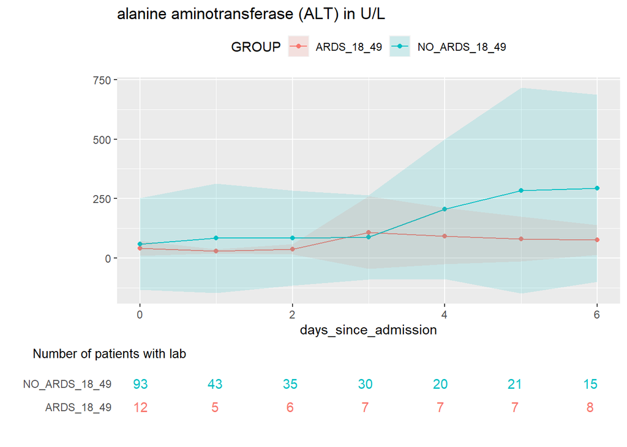

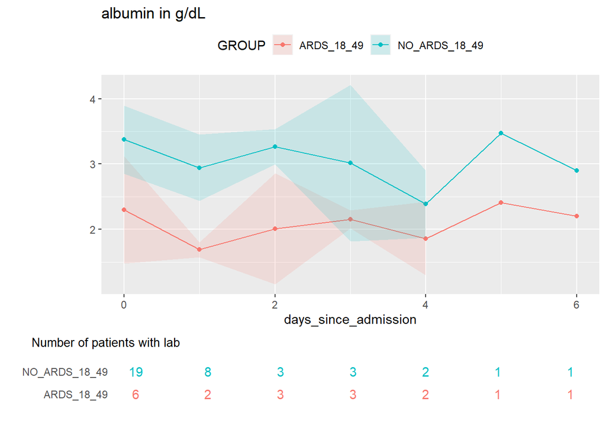

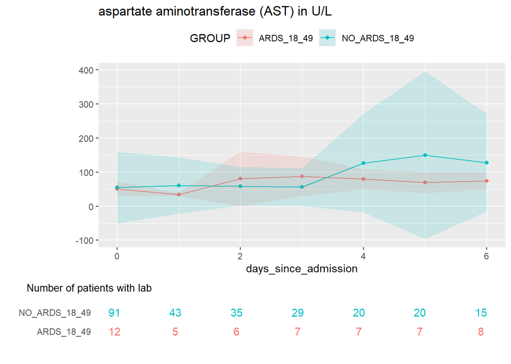

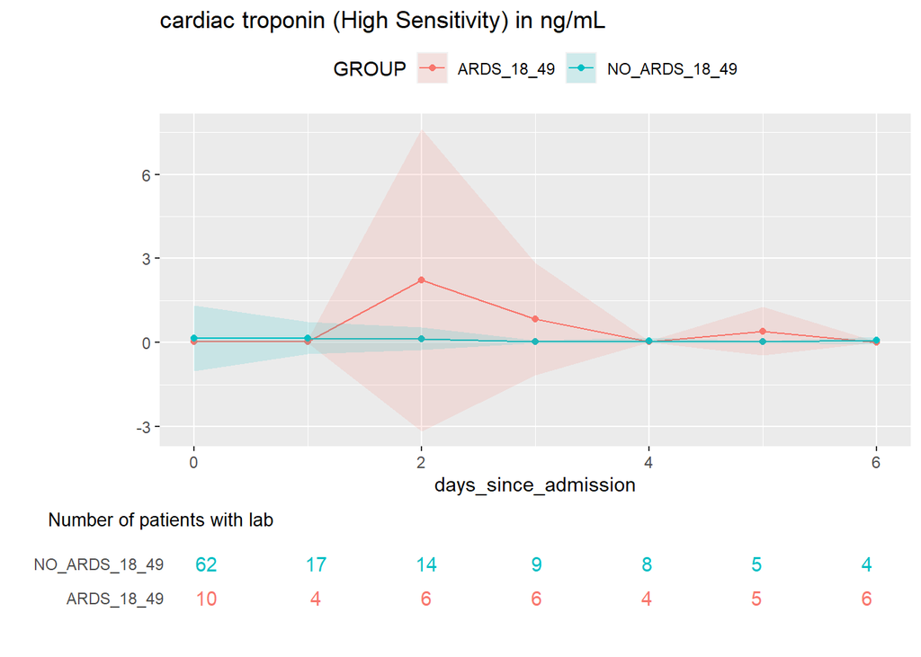

[figure not shown]

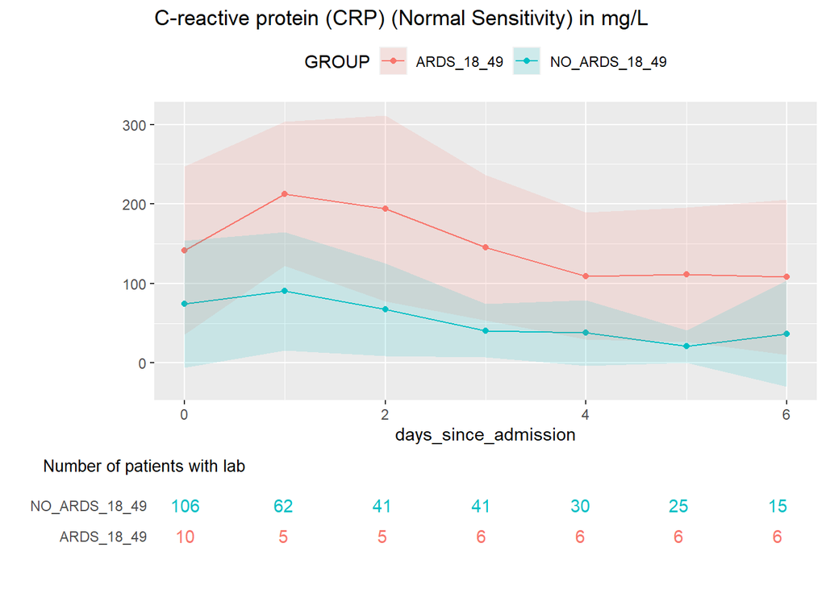

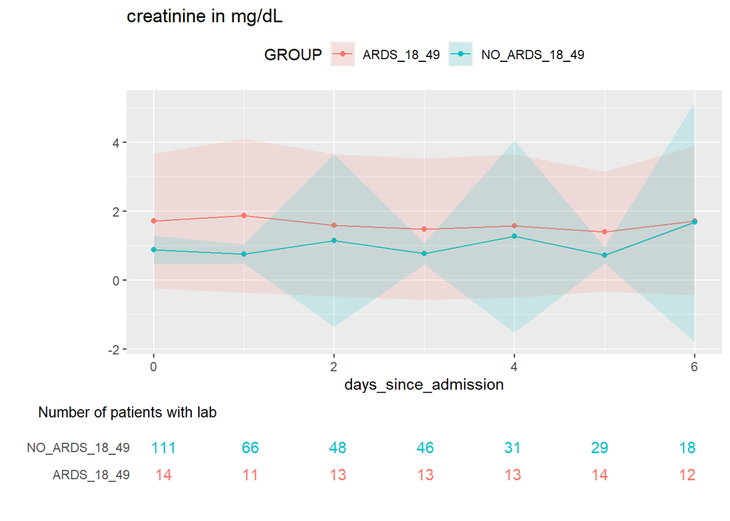

[figure not shown]

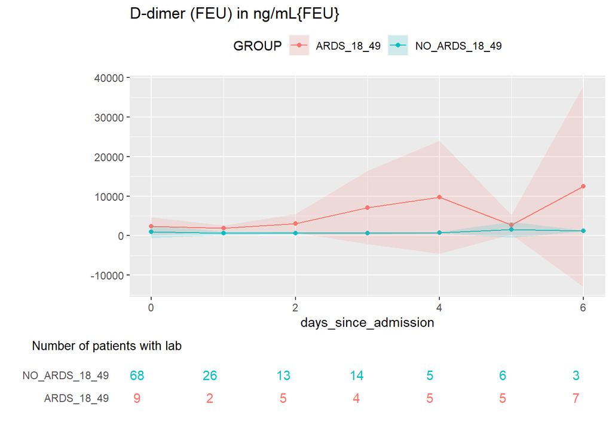

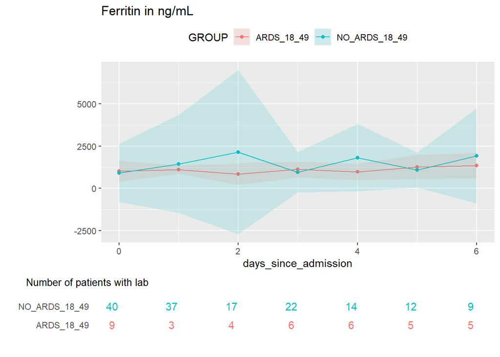

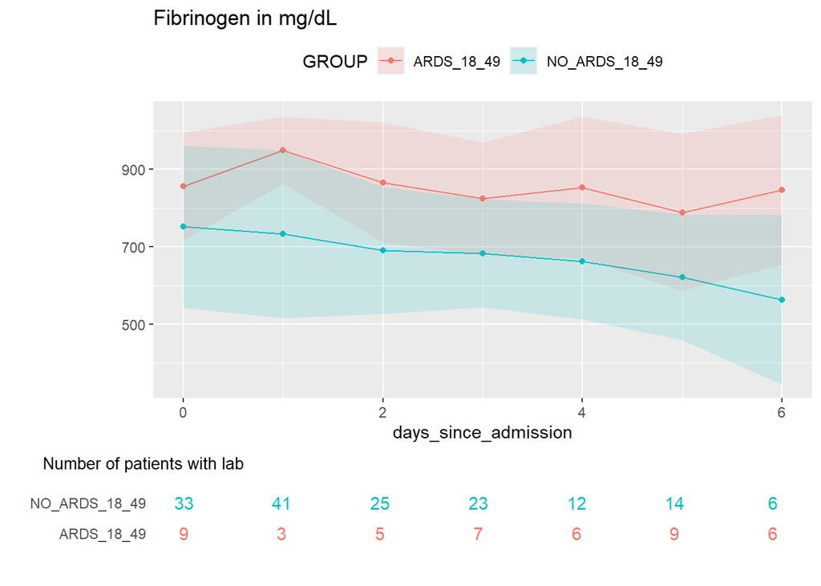

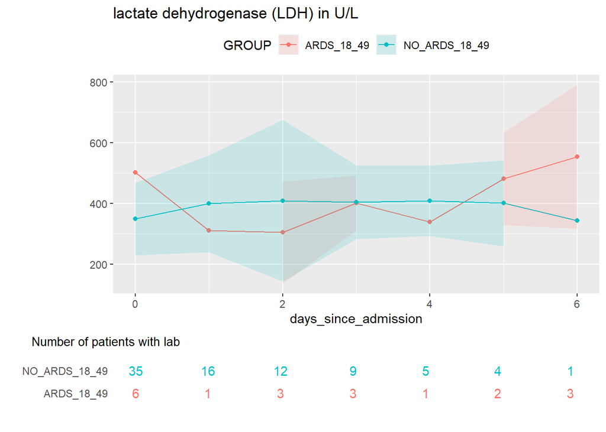

[8 more figures not shown]

[output not shown]

[output cut: 64 more lines]

[output not shown]